# Problem Set 2

Author

Khalid Khogali

Published

October 16, 2026

**GitHub repo:** https://github.com/KhalidKho/ec422_ps2_Khogali

## Data

These are seasonally adjusted monthly unemployment rates for the United States, Oregon, California, Texas, and New York. The data come from FRED and are saved locally.

```r
unemp_raw <- read_rds("data/unemp_raw.rds")

knitr::kable(
  head(unemp_raw),
  caption = "First six rows of the data"
)
```

First six rows of the data

| symbol | date | price |
| --- | --- | --- |
| UNRATE | 1976-01-01 | 7.9 |
| UNRATE | 1976-02-01 | 7.7 |
| UNRATE | 1976-03-01 | 7.6 |
| UNRATE | 1976-04-01 | 7.7 |
| UNRATE | 1976-05-01 | 7.4 |
| UNRATE | 1976-06-01 | 7.6 |

```
The sample covers January 1976 through September 2026.
```

## Wrangling

I renamed the rate column and added region names. Following the instructions, I replaced October 2025 rates with September’s values. I also calculated each region’s monthly change in percentage points.

### Full sample

Mean, minimum, and maximum unemployment rates for each region:

```r
knitr::kable(
  unemp_summary,
  digits = 2,
  col.names = c("Region", "Mean (%)", "Minimum (%)", "Maximum (%)")
)
```

| Region | Mean (%) | Minimum (%) | Maximum (%) |
| --- | --- | --- | --- |
| California | 7.07 | 3.8 | 16.1 |
| New York | 6.35 | 3.8 | 16.7 |
| Oregon | 6.66 | 3.4 | 13.7 |
| Texas | 5.85 | 3.4 | 12.8 |
| United States | 6.05 | 3.4 | 14.8 |

### January 2015 onward

The same statistics for the more recent period:

```r
knitr::kable(
  unemp_recent_summary,
  digits = 2,
  col.names = c("Region", "Mean (%)", "Minimum (%)", "Maximum (%)")
)
```

| Region | Mean (%) | Minimum (%) | Maximum (%) |
| --- | --- | --- | --- |
| California | 5.63 | 3.8 | 16.1 |
| New York | 5.10 | 3.8 | 16.7 |
| Oregon | 4.75 | 3.4 | 13.7 |
| Texas | 4.58 | 3.4 | 12.8 |
| United States | 4.62 | 3.4 | 14.8 |

### Largest increases excluding 2020

The five largest monthly increases, including ties. Changes are measured in percentage points.

```r
unemp_top_increases_no_covid |>
  select(region, date, unemployment_rate, unemployment_rate_change) |>
  knitr::kable(
    digits = 2,
    col.names = c("Region", "Month", "Rate (%)", "Change (pp)")
  )
```

| Region | Month | Rate (%) | Change (pp) |
| --- | --- | --- | --- |
| Texas | 2009-05-01 | 7.6 | 1.1 |
| Oregon | 2008-12-01 | 8.9 | 0.7 |
| Oregon | 2008-11-01 | 8.2 | 0.7 |
| Oregon | 2009-01-01 | 9.6 | 0.7 |
| Oregon | 1980-03-01 | 7.4 | 0.6 |
| United States | 1980-04-01 | 6.9 | 0.6 |

### Largest decreases excluding 2020

The five largest monthly decreases, including ties. Negative values mean unemployment fell.

```r
unemp_top_decreases_no_covid |>
  select(region, date, unemployment_rate, unemployment_rate_change) |>
  knitr::kable(
    digits = 2,
    col.names = c("Region", "Month", "Rate (%)", "Change (pp)")
  )
```

| Region | Month | Rate (%) | Change (pp) |
| --- | --- | --- | --- |
| United States | 1983-07-01 | 9.4 | -0.7 |
| New York | 2021-09-01 | 6.2 | -0.6 |
| Oregon | 1977-05-01 | 7.8 | -0.5 |
| California | 2021-07-01 | 7.4 | -0.5 |
| California | 2021-09-01 | 6.5 | -0.5 |
| New York | 2021-07-01 | 7.0 | -0.5 |
| United States | 2010-12-01 | 9.3 | -0.5 |
| United States | 2014-04-01 | 6.2 | -0.5 |
| United States | 2021-07-01 | 5.4 | -0.5 |

## Visualization

### Unemployment by region

This graph compares all five regions over time.

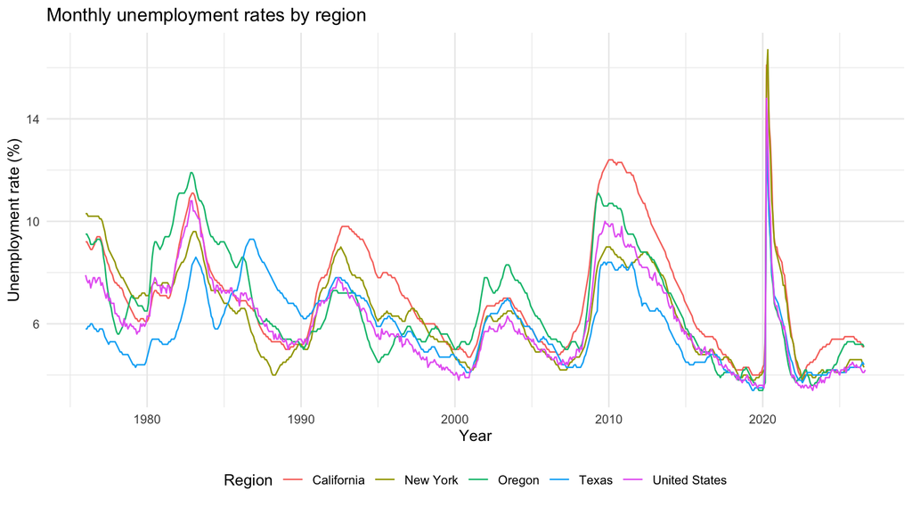

### Separate region graphs

Separate panels make each region easier to follow. They use the same scale for comparison.

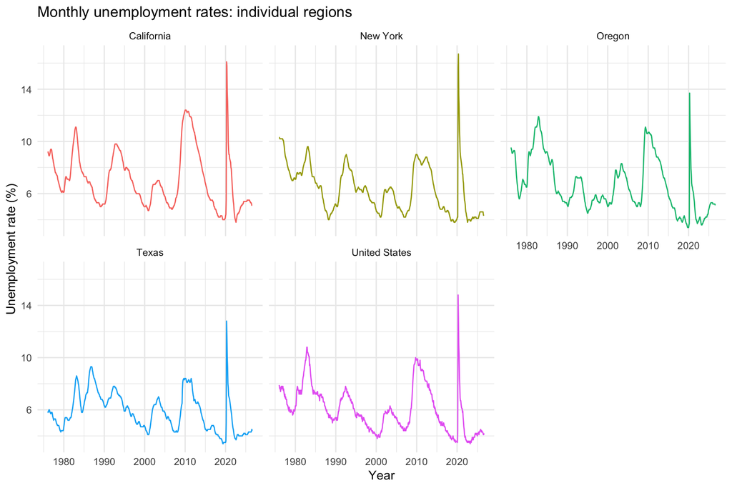

### Average unemployment

Regions are ordered from lowest to highest average unemployment over the full sample.

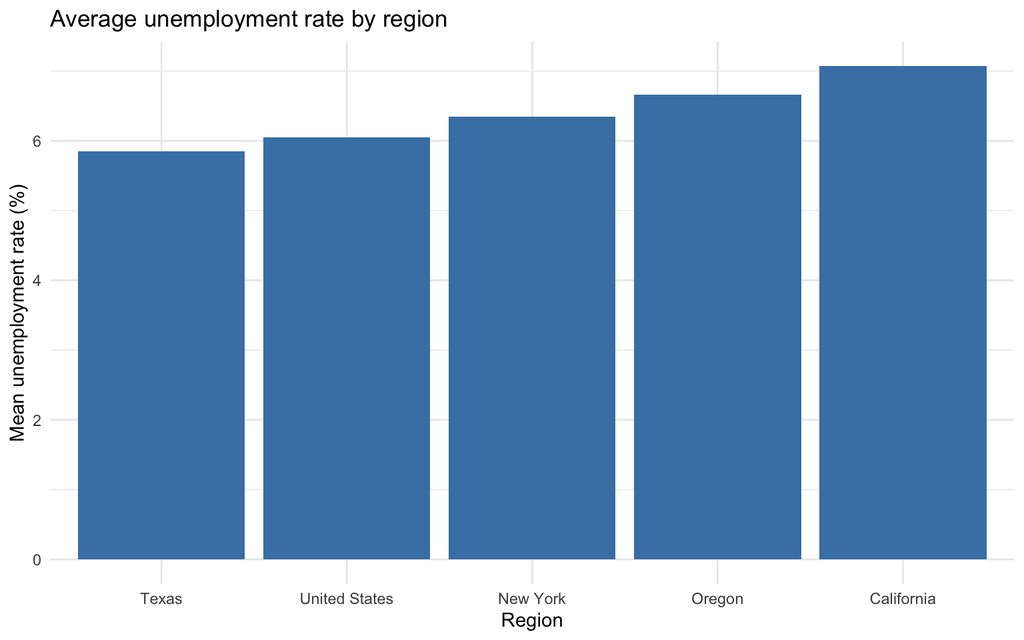

### Oregon and the United States

I chose to compare Oregon with the national rate since 2015 because I wanted to see how unemployment here compares with the country overall. Using just two lines makes the differences easier to see.

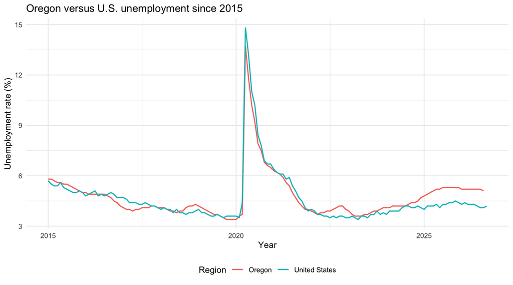

## I used AI to teach me how to write some code and trouble shoot the code I was writing initially. But making the graphs was simple once I had the data ready. I wasn’t sure when to run each block of code. I also had trouble with Git because I hadn’t saved my changes before trying to commit them. I learned that saving, committing, and pushing are separate steps. I feel more comfortable using Git now and checking that my work shows up on GitHub.